### Data Science Capstone - Mileston report

#### November 26, 2016

#### Summary

The goal of this project is to develop a shiny app for predicting the next word based on the user input. This document is a milestone report of the project. The training data is provided by SwiftKey company which are separated as twitter, blogs, and news data sets. Although having more data set will increase the accuracy, it could be computationally expensive. Since the Shiny app or the final product are supposed to be used on small devices we need to have a good understanding about the scaling of the project to handle big data sets. In this report, I load the data into R and do some preliminary data processing. Then I analyze the scale of data in application time. Based on scaling analysis, I choose 1 percent of combination of data and process them. I use “quanteda” package for the quantitative analysis of data. The package provides sets of versatile tools to handle the textual data. After cleaning data, I generate ngrams as well as plots for top features. In the end, the next steps in developing the application are discussed. The shaded box represents more details about the process. Ignoring them will not affect the main point of the report.

#### Required libraries

```r
library(ggplot2)  # Visualization
library(quanteda) # Text mining
```

#### Load data

```r
enUsBlog <- readLines('finalData/en_US/en_US.blogs.txt',skipNul = TRUE)
enUsTwit <- readLines('finalData/en_US/en_US.twitter.txt',skipNul = TRUE)
enUsNews <- readLines('finalData/en_US/en_US.news.txt',skipNul = TRUE)
```

```r
# fileInfo function to concise the file details.
fileInfo <- function(myfile,datasetname){
  MaxNchar <- max(nchar(myfile))
  fsize    <- format(object.size(myfile),units = "Mb")
  flength  <- length(myfile)
  fileInfo <- data.frame("DataSet"=datasetname,
                         "MaxNchar"=MaxNchar,
                         "fileSize.Mb"=fsize,
                         "fileLength"=flength)
}

myinfo.blog <- fileInfo(enUsBlog,"Blog")
myinfo.twit <- fileInfo(enUsTwit,"Twitter")
myinfo.news <- fileInfo(enUsNews,"News")
rbind(myinfo.blog,myinfo.news,myinfo.twit)
```

```
##   DataSet MaxNchar fileSize.Mb fileLength
## 1    Blog    40833    248.5 Mb     899288
## 2    News    11384    249.6 Mb    1010242
## 3 Twitter      140    301.4 Mb    2360148
```

The input data is big. It is necessary to have an idea about the computation time for the portion of data. Before developing the app, I need to make sure that the application predict acceptable results even with limited computational resources. At the current moment, the application could be developed either for prediction or training and prediction. I assume that the final product has an option to get more data set and better train the model. Preprocessing data includes but not limited to:

- Cleaning
  - removing punctuation
  - removing numbers
  - removing URLs
  - removing stopwords
  - removing profanity words
- Tokenizing
- Creating ngrams

At this level I process each step separately, however, later on I will use other commands to merge the processes.

```r
# function to sample the data set
sampleData <- function(data1,data2,data3,samplePercent){
  sampleData1 <- sample(data1, floor(length(data1)*samplePercent))
  sampleData2 <- sample(data2, floor(length(data2)*samplePercent))
  sampleData3 <- sample(data3, floor(length(data3)*samplePercent))
  sampleData  <- rbind(sampleData1,sampleData2,sampleData3)
}

# Data percentage
sampleP <- c(0.01,0.02,0.03,0.04,0.05,0.06,0.07,0.08,0.09,0.1,0.2)

alldata <- NULL
GB <- 1.25 * 10 ^ 8

for (i in sampleP){

  sampleText    <- sampleData(enUsBlog,enUsTwit,enUsNews,samplePercent = i)
  sampleSize    <- format(object.size(sampleText),units = "Mb")
  sampleSize    <- as.numeric(gsub("[a-zA-Z]","",sampleSize))
  sampleLength  <- length(sampleText)
  samplePer     <- i
  # Tokenization time
  tokentime     <- as.numeric(system.time(tokenizedT
                                          <- tokenize(sampleText,
                                                      removeNumbers = TRUE,
                                                      removePunct = TRUE,
                                                      removeURL = TRUE) )[3])
  # Creating ngrams time
  ngrams.1.t    <- as.numeric(system.time(ngrams.1 <- ngrams(tokenizedT, n=1))[3])
  ngrams.2.t    <- as.numeric(system.time(ngrams.2 <- ngrams(tokenizedT, n=2))[3])
  ngrams.3.t    <- as.numeric(system.time(ngrams.3 <- ngrams(tokenizedT, n=3))[3])

  # ngrams size on memory
  ngrams.1.s    <- as.numeric(gsub("[a-zA-Z]","",object.size(ngrams.1)))
  ngrams.2.s    <- as.numeric(gsub("[a-zA-Z]","",object.size(ngrams.2)))
  ngrams.3.s    <- as.numeric(gsub("[a-zA-Z]","",object.size(ngrams.3)))

  sample.i      <- data.frame("size"=sampleSize,
                              "length"=sampleLength,
                              "Percent"=samplePer,
                              "TokenTime" = tokentime,
                              "ngrams1t"=ngrams.1.t,
                              "ngrams2t"=ngrams.2.t,
                              "ngrams3t"=ngrams.3.t,
                              "ngrams1s"=ngrams.1.s/GB,
                              "ngrams2s"=ngrams.2.s/GB,
                              "ngrams3s"=ngrams.3.s/GB)
  alldata       <- rbind(alldata,sample.i)
}

alldata
```

```
##     size  length Percent TokenTime ngrams1t ngrams2t ngrams3t   ngrams1s
## 1    8.2   70803    0.01     3.262    2.179    6.760    8.983  0.8310449
## 2   16.4  141606    0.02     3.704    4.523   14.360   17.554  1.6580698
## 3   24.7  212412    0.03     5.986    7.902   21.372   34.179  2.5000852
## 4   32.9  283215    0.04     8.005   10.064   30.169   36.298  3.3240392
## 5   41.2  354021    0.05     9.951   11.118   36.271   44.555  4.1702798
## 6   49.4  424824    0.06    12.383   15.973   48.655   60.554  4.9979310
## 7   57.7  495630    0.07    15.761   20.181   56.841   63.557  5.8330861
## 8   66.0  566433    0.08    17.662   20.472   63.414   84.865  6.6841685
## 9   74.2  637239    0.09    19.361   31.204   78.765   97.829  7.5095460
## 10  82.2  708042    0.10    20.743   26.867   79.505   98.664  8.3111359
## 11 164.6 1416087    0.20    41.018   48.425  154.471  213.460 16.6667830
##     ngrams2s  ngrams3s
## 1   1.010021  1.109001
## 2   2.017540  2.214626
## 3   3.043331  3.341470
## 4   4.048621  4.445144
## 5   5.075722  5.572349
## 6   6.083058  6.678277
## 7   7.103750  7.798663
## 8   8.141937  8.940706
## 9   9.147770 10.045559
## 10 10.111688 11.098569
## 11 20.300959 22.289844
```

Following graph shows the variation of time (tokenization and creation of ngrams ) for different data sample. Although there are better methods for profiling the process, this function is to get an idea about the relative scales between subsamples.Here is the system configuration: Mac: OS X El Capitan, Processor 3.2 GHz Intel, Memory 32 GB 1600 MHz DDR3

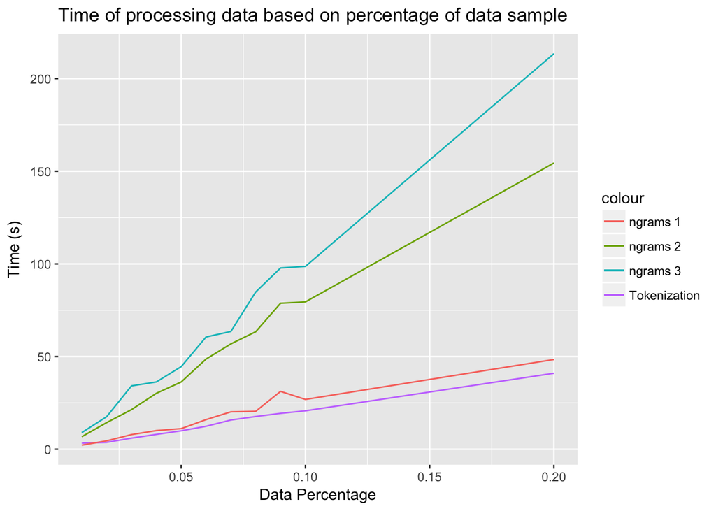

```r
ggplot(alldata, aes(x=Percent)) + geom_line(aes(y=TokenTime, colour="Tokenization")) +
  geom_line(aes(y=ngrams1t, colour="ngrams 1")) +
  geom_line(aes(y=ngrams2t, colour="ngrams 2")) +
  geom_line(aes(y=ngrams3t, colour="ngrams 3")) +
  labs(x="Data Percentage",y="Time (s)", title="Time of processing data based on percentage of data sample")
```

Other than time, memory also is an important factor. The following plot shows the size of each variables.

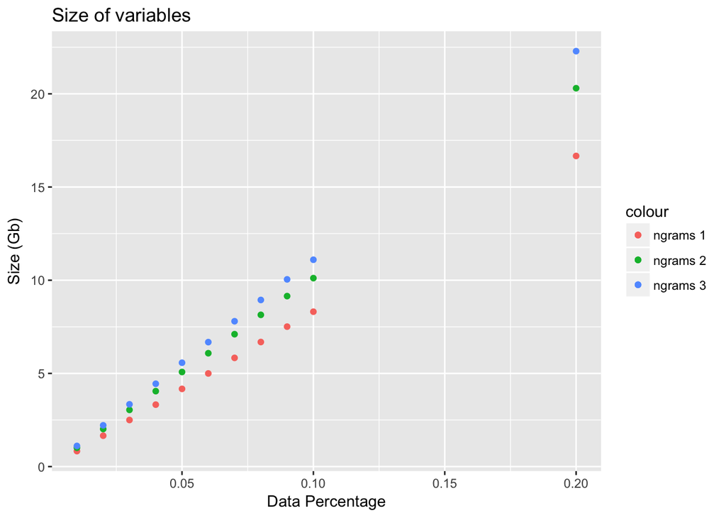

```r
ggplot(alldata, aes(x=Percent)) +
  geom_point(aes(y=ngrams1s, colour="ngrams 1 ")) +
  geom_point(aes(y=ngrams2s, colour="ngrams 2 ")) +
  geom_point(aes(y=ngrams3s, colour="ngrams 3 ")) +
  labs(x="Data Percentage",y="Size (Gb)", title="Size of variables")
```

Even small portion of data, create a large ngrams variable. I resample 1 percent of data and process and provide some statistics on the results. The cleaning process also includes removing stop words and profanity words. The quanteda package has the English stop words. I downloaded a vector of profanity words. Obviously it could be a subjective decision and the list could be shorter or longer than the current one.

```r
# Sample 5 percent of data
sampleText.5    <- sampleData(enUsBlog,enUsTwit,enUsNews,samplePercent = 0.01)
profdictionary <- readLines('profanitywords.txt')

# Document-feature matrix
dfm.ngram.1 <- dfm(sampleText.5, ngrams=1, verbose = FALSE,
                   concatenator = " ", stopwords=TRUE,
                   removeNumbers = TRUE, removePunct = TRUE,
                   removeSeparators = TRUE,
                   ignoredFeatures=c(profdictionary,stopwords(kind = "english", verbose = FALSE))
                   )

dfm.ngram.2 <- dfm(sampleText.5, ngrams=2, verbose = FALSE,
                   concatenator = " ", stopwords=TRUE,
                   removeNumbers = TRUE, removePunct = TRUE,
                   removeSeparators = TRUE,
                   ignoredFeatures=c(profdictionary,stopwords(kind = "english", verbose = FALSE))
                   )

dfm.ngram.3 <- dfm(sampleText.5, ngrams=3, verbose = TRUE,
                   concatenator = " ", stopwords=TRUE,
                   removeNumbers = TRUE, removePunct = TRUE,
                   removeSeparators = TRUE,
                   ignoredFeatures=c(profdictionary,stopwords(kind = "english", verbose = FALSE))
                   )
```

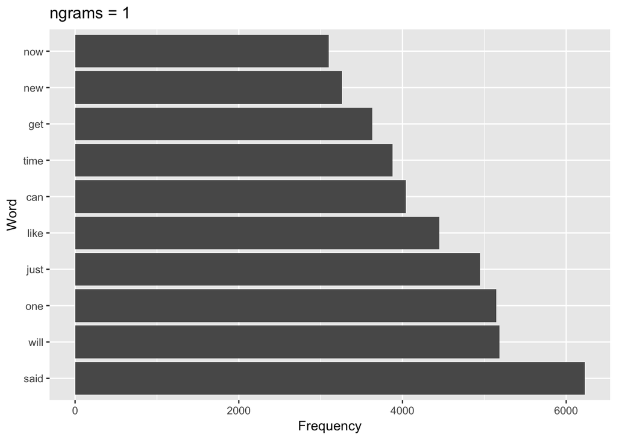

```r
# number of features
fnumber <- 10
# using docfreq to extract the frequency of features
f.ngrams.1 <- as.data.frame(as.matrix(docfreq(dfm.ngram.1)))
f.ngrams.2 <- as.data.frame(as.matrix(docfreq(dfm.ngram.2)))
f.ngrams.3 <- as.data.frame(as.matrix(docfreq(dfm.ngram.3)))
# Sort the features
f.ngrams.1.s <- sort(rowSums(f.ngrams.1), decreasing=TRUE)
f.ngrams.2.s <- sort(rowSums(f.ngrams.2), decreasing=TRUE)
f.ngrams.3.s <- sort(rowSums(f.ngrams.3), decreasing=TRUE)
# generate a dataframe
ngrams.d.1 <- data.frame(Word=factor(names(f.ngrams.1.s)), Freq = f.ngrams.1.s)
ngrams.d.2 <- data.frame(Word=factor(names(f.ngrams.2.s)), Freq = f.ngrams.2.s)
ngrams.d.3 <- data.frame(Word=factor(names(f.ngrams.3.s)), Freq = f.ngrams.3.s)

ggplot(ngrams.d.1[1:fnumber,],aes(x=reorder(Word,-Freq),y=Freq))+
                              geom_bar(stat = "identity") + coord_flip()+
                              labs(x="Word",y="Frequency",
                              title="ngrams = 1")
```

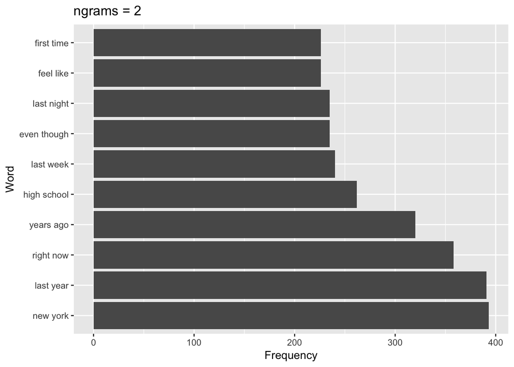

```r
ggplot(ngrams.d.2[1:fnumber,],aes(x=reorder(Word,-Freq),y=Freq))+
                              geom_bar(stat = "identity") + coord_flip()+
                              labs(x="Word",y="Frequency",
                              title="ngrams = 2")
```

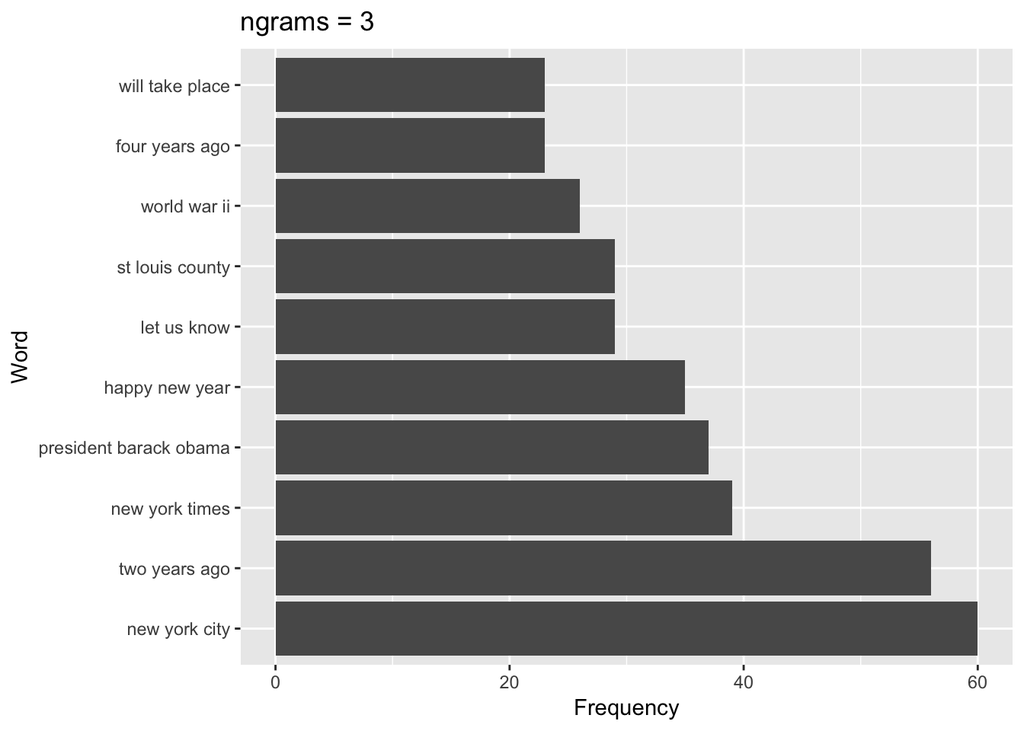

```r
ggplot(ngrams.d.3[1:fnumber,],aes(x=reorder(Word,-Freq),y=Freq))+
                              geom_bar(stat = "identity") + coord_flip()+
                              labs(x="Word",y="Frequency",
                              title="ngrams = 3")
```

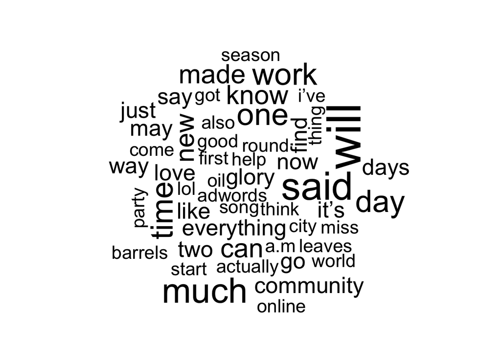

```r
plot(dfm.ngram.1[1:100])
```

Up to this point, I load the data and cleaned it. Also the ngrams developed for the data. The next step is compressing these steps to develop the application.

#### Developing Shiny App

The goal of this project is developing a shiny application based on the provided data. For the app the following factors should be considered:

- The target device of the application (For scaling data)
- Is there a training option for customized text?
- Is there a other languages options?
- Do you want to have an accuracy analysis?

Also there should be a comprehensive function to do all steps for different language options. I haven’t studied the ability to do parallel processing for the application, however, it could be good to have that option. After deciding on the application’s general features and capabilities, I need to come up with a good prediction model.